# Advanced statistics for physics analysis - Exercise 3

Matteo Bortoletto, matr. 1242935

23/04/2020

## Exercise 1

The time it takes a student to complete a TOLC-I University orientation and evaluation test follows a density function of the form

$$f(X) = \begin{cases}
c(t-1)(2-t) & 1<t<2 \\
0 & otherwise
\end{cases}$$

where $t$ is the time in hours.

1. using the `integrate()` R function, determine the constant $c$ (and verify it analytically);

```r
one_over_c <- integrate(function(t) {(t-1)*(2-t)}, lower=1, upper=2)
one_over_c$value^(-1)
```

```
## [1] 6
```

```r
pdf_f <- function(t) { func <- ifelse(t>1 & t<2, 6*(t-1)*(2-t), 0)
  return(func)
}

cdf_f <- function(t) { func <- ifelse(t<1, 0,
                                      ifelse(t<=2, 9*t^2 - 2*t^3 - 12*t + 5,
                                             1))
  return(func)
}

# the CDF is not easily invertible, so I use the acceptance/rejection method
r_f <- function(x) {
  a <- 1
  b <- 2
  n <- 10000
  udist1 <- runif(n, a, b)
  udist2 <- runif(n, 0, 1)
  f.max <- 1.5
  y <- ifelse(udist2 * f_max < pdf_f(udist1), udist1, NA)
  y.clean <- y[!is.na(y)]
  return(y.clean[1:x])
}

q_f <- function(p) {
  cdf_values <- cdf_f(seq(1,2,0.001))
  x <- max(cdf_values[cdf_values<p])
  return(x)
}
```

3. evaluate the probability that the student will finish the aptitude test in more than 75 minutes. And that it will take 90 and 120 minutes.

```r
more75 <- 1-cdf_f(1.25) # 75 minutes = 1.25 hours
paste("The probability that the student will finish the aptitude test in more than 75 minutes is", more75)
```

```
## [1] "The probability that the student will finish the aptitude test in more than 75 minutes is 0.84375"
```

```r
# my guess is that the exercise asks for the time *between* 90 and 120 minutes
betw90and120 <- cdf_f(2)-cdf_f(1.5)
paste("The probability that the student will finish the aptitude test in 90 minutes is", betw90and120)
```

```
## [1] "The probability that the student will finish the aptitude test in 90 minutes is 0.5"
```

## Exercise 2

The lifetime of tires sold by an used tires shop is $10^4\cdot x$ km, where $x$ is a random variable following the distribution function

$$f(X) = \begin{cases}
2/x^2 & 1 < x < 2 \\
0 & otherwise
\end{cases}$$

1. write the set of four R functions and plot the pdf and cdf, respectively;

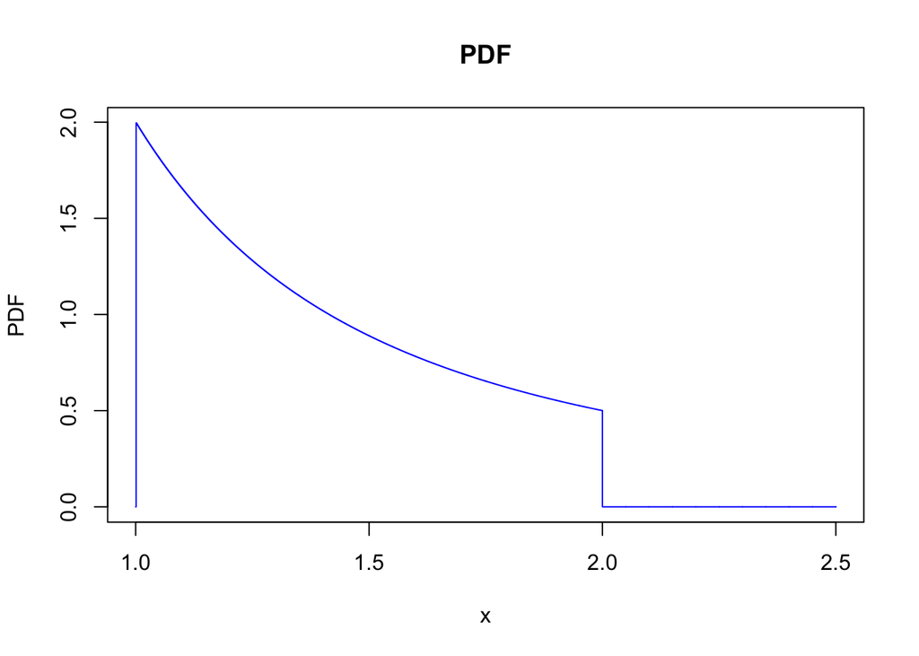

```r
pdf_f <- function(t) { func <- ifelse(t>1 & t<2, 2/(x^2), 0)
  return(func)
}

cdf_f <- function(t) { func <- ifelse(t<1, 0,
                                      ifelse(t<=2, 2 - 2/t,
                                             1))
  return(func)
}

r_f <- function(n) {
  u1 <- runif(n, 0, 1)
  inv_cdf <- 2/(2-u1)
  return(inv_cdf[1:n])
}

q_f <- function(p) {
  cdf_values <- cdf_f(seq(1,2,0.001))
  x <- max(cdf_values[cdf_values<p])
  return(x)
}

x <- seq(1,2.5,0.001)
plot(x, pdf_f(x),
     xlab = "x",
     ylab = "PDF",
     type = "s",
     col = "blue",
     main = "PDF")
```

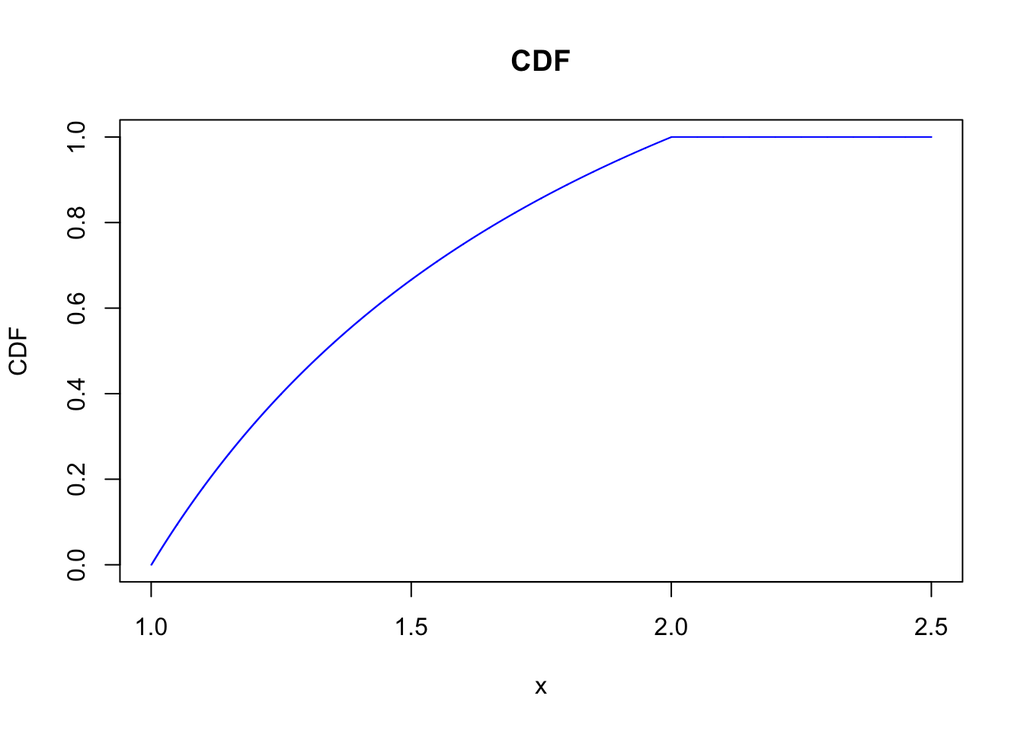

```r
plot(x, cdf_f(x),
     xlab = "x",
     ylab = "CDF",
     type = "s",
     col = "blue",
     main = "CDF")
```

2. determine the probability that tires will last less than 15000 km;

```r
less15000 <- cdf_f(1.5)
paste("The probability that the tires will last less than 15000 km is", less15000)
```

```
## [1] "The probability that the tires will last less than 15000 km is 0.666666666666667"
```

3. sample 3000 random variables from the distribution and determine the mean value and the variance, using the expression $Var(X) = E[X^2] − E[X]^2$.

```r
samples <- r_f(3000)
m <- mean(samples)
v <- mean(samples^2)-m^2
paste("The mean is", m, "and the variance is", v)
```

```
## [1] "The mean is 1.38781478093627 and the variance is 0.0779843801847377"
```

## Exercise 3

Markov’s inequality represents an upper boud to probability distributions:

$$P(X \geq k) \leq \frac{E[X]}{k} \qquad \text{for } k>0$$
having defined a function

$$G(k) = 1-F(k) \equiv P(X \geq k)$$

plot $G(k)$ and the Markov’s upper bound for:

1. the exponential, Exp$(\lambda= 1)$, distribution function;

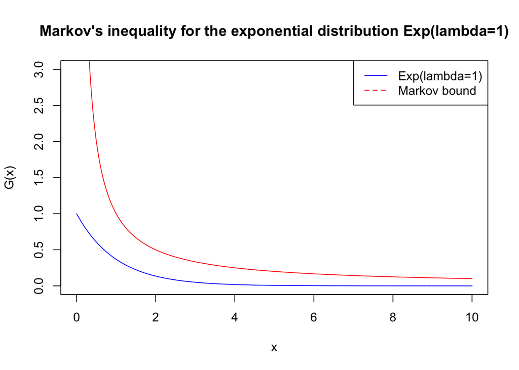

```r
library(ggplot2)

G_exp <- function(x) {
  return(1-pexp(x))
}

Markov_exp <- function(x) {
  return(1/x)
}

x <- seq(0,10,0.001)

plot(x, G_exp(x),
     type='l',
     main="Markov's inequality for the exponential distribution Exp(lambda=1)",
     xlab="x",
     ylab="G(x)",
     xlim = c(0,10),
     ylim=c(0,3),
     col = "blue")

lines(x, Markov_exp(x),
      col = "red")

legend("topright",
       legend=c("Exp(lambda=1)", "Markov bound"),
       col=c("blue", "red"),
       lty=1:2)
```

2. the uniform, $\mathcal{U}(3,5)$, distribution function;

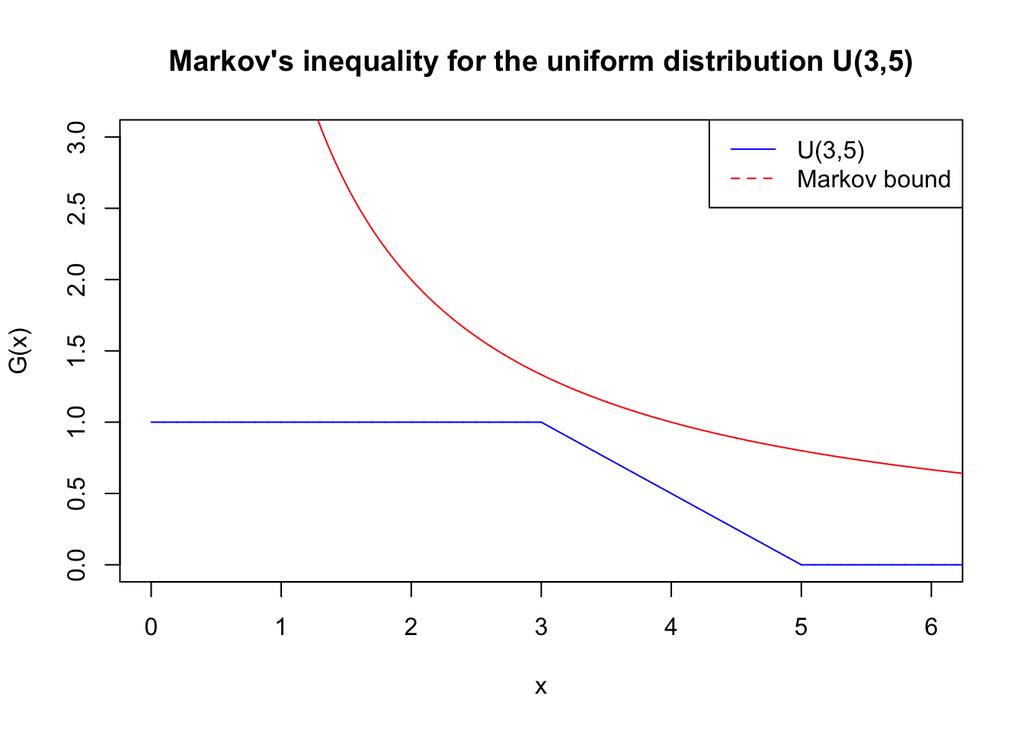

```r
G_unif <- function(x) {
  return(1-punif(x,3,5))
}

Markov_unif <- function(x) {
  return(4/x)
}

x <- seq(0,10,0.001)

plot(x, G_unif(x),
     type='l',
     main="Markov's inequality for the uniform distribution U(3,5)",
     xlab="x",
     ylab="G(x)",
     xlim = c(0,6),
     ylim=c(0,3),
     col = "blue")

lines(x, Markov_unif(x),
      col = "red")

legend("topright",
       legend=c("U(3,5)", "Markov bound"),
       col=c("blue", "red"),
       lty=1:2)
```

3. the binomial, Bin$(n = 1, p = 1/2)$, distribution function;

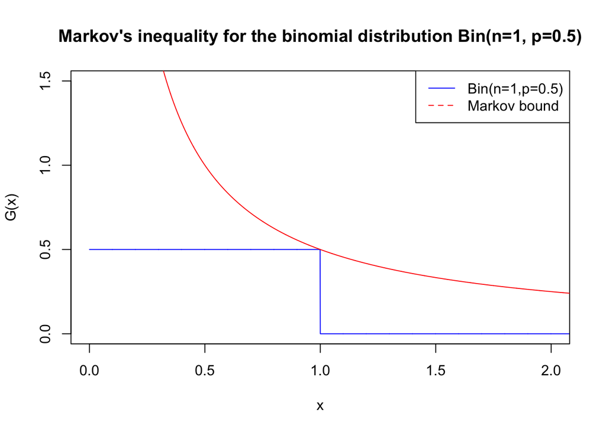

```r
G_binom <- function(x) {
  return(1-pbinom(x,1,0.5))
}

Markov_binom <- function(x) {
  return(0.5/x)
}

x <- seq(0,10,0.001)

plot(x, G_binom(x),
     type='l',
     main="Markov's inequality for the binomial distribution Bin(n=1, p=0.5)",
     xlab="x",
     ylab="G(x)",
     xlim = c(0,2),
     ylim=c(0,1.5),
     col = "blue")

lines(x, Markov_binom(x),
      col = "red")

legend("topright",
       legend=c("Bin(n=1,p=0.5)", "Markov bound"),
       col=c("blue", "red"),
       lty=1:2)
```

4. a Poisson, Pois$(\lambda = 1/2)$, distribution function.

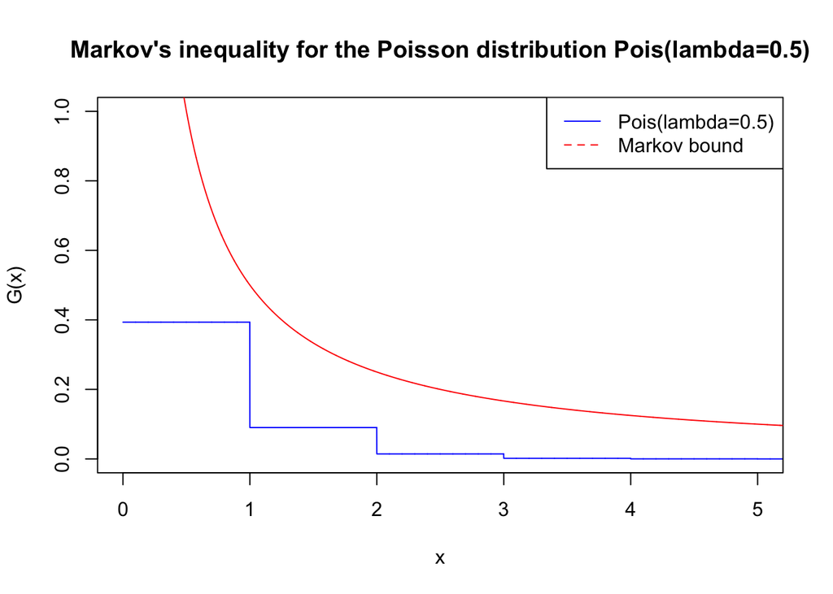

```r
G_pois<- function(x) {
  return(1-ppois(x,0.5))
}

Markov_pois <- function(x) {
  return(0.5/x)
}

x <- seq(0,10,0.001)

plot(x, G_pois(x),
     type='l',
     main="Markov's inequality for the Poisson distribution Pois(lambda=0.5)",
     xlab="x",
     ylab="G(x)",
     xlim = c(0,5),
     ylim=c(0,1),
     col = "blue")

lines(x, Markov_pois(x),
      col = "red")

legend("topright",
       legend=c("Pois(lambda=0.5)", "Markov bound"),
       col=c("blue", "red"),
       lty=1:2)
```

## Exercise 4

Chebyshev’s inequality tells us that

$$P\left(\left| X - \mu \right| \geq k \sigma \right) \leq \frac{1}{k^2}$$
which can also be written as

$$P\left(\left| \frac{X-\mu}{\sigma}\right|<k\right) \geq 1 - \frac{1}{k^2}$$
use R to show, with a plot, that Chebyshev’s inequality is an upper bound to the following distributions:

1. a normal distribution, $N(\mu = 3, \sigma = 5)$

```r
chebyshev <- function(x) {
  return (1-(1/x^2))
}
```

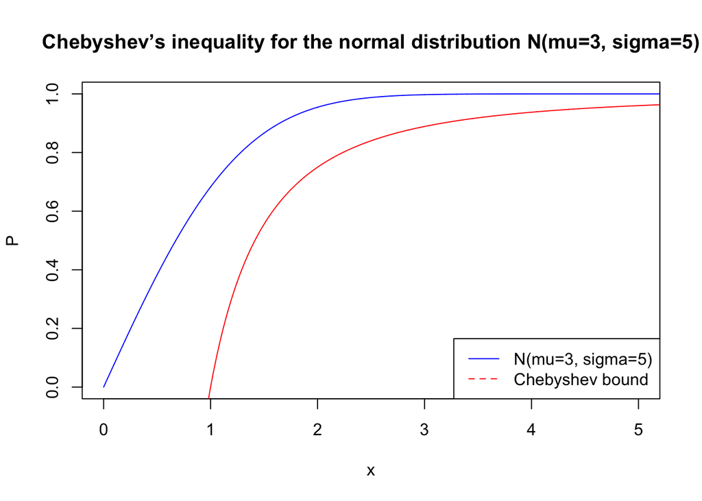

```r
# mu = 3
# sigma = 5
g <- function(x) {
  return(pnorm((5*x+3),3,5)-pnorm(3-5*x,3,5))
}

x <- seq(0,10,0.001)

plot(x, g(x),
     type='l',
     main="Chebyshev’s inequality for the normal distribution N(mu=3, sigma=5)",
     xlab="x",
     ylab="P",
     xlim = c(0,5),
     ylim=c(0,1),
     col = "blue")

lines(x, chebyshev(x),
      col = "red")

legend("bottomright",
       legend=c("N(mu=3, sigma=5)", "Chebyshev bound"),
       col=c("blue", "red"),
       lty=1:2)
```

2. an exponential distribution, Exp$(\lambda = 1)$

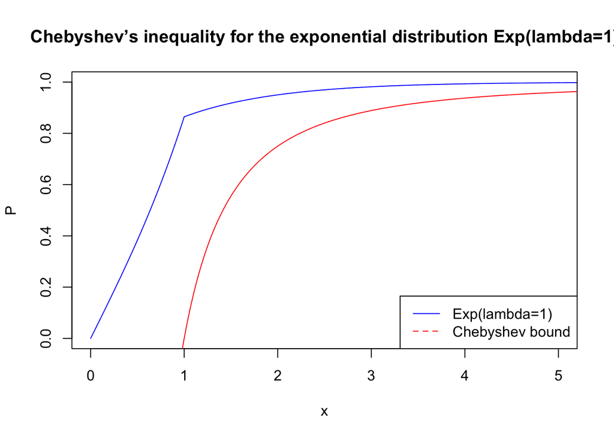

```r
# mu = 1/lambda
# sigma = 1/lambda^2
e <- function(x) {
  return(pexp(1+x)-pexp(1-x))
}

x <- seq(0,10,0.001)

plot(x, e(x),
     type='l',
     main="Chebyshev’s inequality for the exponential distribution Exp(lambda=1)",
     xlab="x",
     ylab="P",
     xlim = c(0,5),
     ylim=c(0,1),
     col = "blue")

lines(x, chebyshev(x),
      col = "red")

legend("bottomright",
       legend=c("Exp(lambda=1)", "Chebyshev bound"),
       col=c("blue", "red"),
       lty=1:2)
```

3. a uniform distribution $\mathcal{U}(1 − \sqrt{2}, 1 + \sqrt{2})$

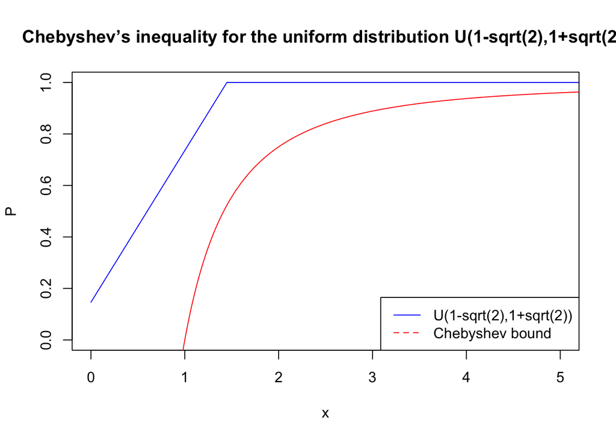

```r
# mu = 0
# sigma = (b^2+a^2-ab)/3 = 5/3
u <- function(x) {
  return(punif(x*5/3,1-2^(1/2),1+2^(1/2))-punif(-x*5/3,1-2^(1-2),1+2^(1/2)))
}

x <- seq(0,10,0.001)

plot(x, u(x),
     type='l',
     main="Chebyshev’s inequality for the uniform distribution U(1-sqrt(2),1+sqrt(2))",
     xlab="x",
     ylab="P",
     xlim = c(0,5),
     ylim=c(0,1),
     col = "blue")

lines(x, chebyshev(x),
      col = "red")

legend("bottomright",
       legend=c("U(1-sqrt(2),1+sqrt(2))", "Chebyshev bound"),
       col=c("blue", "red"),
       lty=1:2)
```

4. a Poisson, $Pois(\lambda = 1/3)$, distribution function

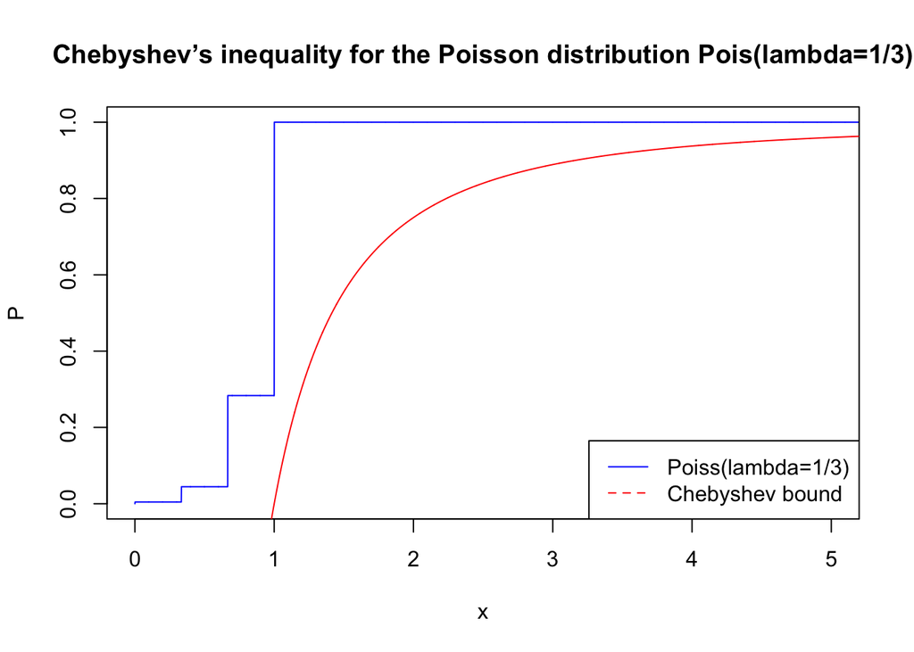

```r
# mu = 1/lambda
# sigma = 1/lambda
p <- function(x) {
  return(ppois(x*3+3,1/3)-ppois(3-x*3,1/3))
}

x <- seq(0,10,0.001)

plot(x, p(x),
     type='l',
     main="Chebyshev’s inequality for the Poisson distribution Pois(lambda=1/3)",
     xlab="x",
     ylab="P",
     xlim = c(0,5),
     ylim=c(0,1),
     col = "blue")

lines(x, chebyshev(x),
      col = "red")

legend("bottomright",
       legend=c("Poiss(lambda=1/3)", "Chebyshev bound"),
       col=c("blue", "red"),
       lty=1:2)
```